# New York Solar Resource data

Sofiane Ikkour

### **Context:**

In this use case, we’ll work with [Solar Resource Data](https://developer.nrel.gov/docs/solar/solar-resource-v1/) which returns various types of solar data for a location. The location here is the city of New York. We will use application programming interfaces (APIs) from a [Web service documentation](https://api.data.gov/docs/) to access and manipulate many federal agencies’s datasets with information about the United States that covers several topics.

### **Goal:**

Our goal is to use APIs to extract the solar resource data for New York City in JSON format and convert it into a dataframe.

**Note:** This code was written on RStudio.  
**Language:** R.  
**Packages:** httr, jsonlite, tibble, dplyr, ggplot2.

**query the API**

The [Web service](https://api.data.gov/docs/) needs an access key. I got one using this [link](https://api.data.gov/signup/) after signing up for an API key to access and use web services available on the Data.gov developer network. The API key is “Ra7jcVZGuhjMsuyLhErfGQJIgFC0sJcfkaSvSRpV”.

```r
# load the relevant libraries
library(httr)
library(jsonlite)
library(tibble)
library(dplyr)
```

```r
library(ggplot2)

# store the api key in variable
api_key <- "Ra7jcVZGuhjMsuyLhErfGQJIgFC0sJcfkaSvSRpV"

# identify and store the url we'll need to extract the New York City Solar Resource Data in JSON format
api_url <- "https://developer.nrel.gov/api/solar/solar_resource/v1.json"

# store the following parameters api_key, lat (latitude = 41), lon (longitude = -75) in a list
parameters_list <- list(api_key = api_key, lat = 41, lon = -75)
```

Now that we have identified the URL and the parameters we need to query the API.

```r
# use GET() function to request the data from the API with url and parameters_list
response <- GET(api_url, query = parameters_list)

# display the status code
status <- status_code(response)
print(paste("Status code:", status))
```

```
## [1] "Status code: 200"
```

```r
# display the API response format
response_format <- http_type(response)
print(paste("Response format:", response_format))
```

```
## [1] "Response format: application/json"
```

```r
# extract the API response content as text
content <- content(response, "text")

# display the content
print("Content:")
```

```
## [1] "Content:"
```

```r
cat("\n")
```

```r
print(content)
```

```
## [1] "{\"version\":\"1.0.0\",\"warnings\":[],\"errors\":[],\"metadata\":{\"sources\":[\"Perez-SUNY/NREL, 2012\"]},\"inputs\":{\"lat\":\"41\",\"lon\":\"-75\"},\"outputs\":{\"avg_dni\":{\"annual\":3.69,\"monthly\":{\"jan\":3.12,\"feb\":3.36,\"mar\":4.1,\"apr\":4.07,\"may\":4.15,\"jun\":4.17,\"jul\":…
```

The API response content is a JSON text that we will convert into an R object that we can manipulate.

**convert the API response into an R object**

```r
# parse the API response content to an R object
json_lists <- fromJSON(content)

# display the structure of the R object
str(json_lists)
```

```
## List of 6
##  $ version : chr "1.0.0"
##  $ warnings: list()
##  $ errors  : list()
##  $ metadata:List of 1
##   ..$ sources: chr "Perez-SUNY/NREL, 2012"
##  $ inputs  :List of 2
##   ..$ lat: chr "41"
##   ..$ lon: chr "-75"
##  $ outputs :List of 3
##   ..$ avg_dni     :List of 2
##   .. ..$ annual : num 3.69
##   .. ..$ monthly:List of 12
##   .. .. ..$ jan: num 3.12
##   .. .. ..$ feb: num 3.36
##   .. .. ..$ mar: num 4.1
##   .. .. ..$ apr: num 4.07
##   .. .. ..$ may: num 4.15
##   .. .. ..$ jun: num 4.17
##   .. .. ..$ jul: num 4.6
##   .. .. ..$ aug: num 4.14
##   .. .. ..$ sep: num 4.02
##   .. .. ..$ oct: num 3.26
##   .. .. ..$ nov: num 2.58
##   .. .. ..$ dec: num 2.72
##   ..$ avg_ghi     :List of 2
##   .. ..$ annual : num 3.87
##   .. ..$ monthly:List of 12
##   .. .. ..$ jan: num 1.97
##   .. .. ..$ feb: num 2.69
##   .. .. ..$ mar: num 3.86
##   .. .. ..$ apr: num 4.7
##   .. .. ..$ may: num 5.45
##   .. .. ..$ jun: num 5.78
##   .. .. ..$ jul: num 5.98
##   .. .. ..$ aug: num 5.14
##   .. .. ..$ sep: num 4.23
##   .. .. ..$ oct: num 2.94
##   .. .. ..$ nov: num 1.99
##   .. .. ..$ dec: num 1.67
##   ..$ avg_lat_tilt:List of 2
##   .. ..$ annual : num 4.52
##   .. ..$ monthly:List of 12
##   .. .. ..$ jan: num 3.55
##   .. .. ..$ feb: num 4.04
##   .. .. ..$ mar: num 4.86
##   .. .. ..$ apr: num 4.97
##   .. .. ..$ may: num 5.18
##   .. .. ..$ jun: num 5.24
##   .. .. ..$ jul: num 5.58
##   .. .. ..$ aug: num 5.24
##   .. .. ..$ sep: num 5
##   .. .. ..$ oct: num 4.11
##   .. .. ..$ nov: num 3.26
##   .. .. ..$ dec: num 3.13
```

After parsing the JSON data into an R object we got a complex list. We need to convert this list into a dataframe.

**convert json_lists into a dataframe**

```r
# first, extract the 'outputs' list from the json_lists
outputs_list <- json_lists$outputs

# second, extract the monthly vector 'monthly' from the following lists: avg_dni, avg_ghi, avg_lat_tilt
avg_dni_monthly <- as.numeric(outputs_list$avg_dni$monthly)
avg_ghi_monthly <- as.numeric(outputs_list$avg_ghi$monthly)
avg_lat_tilt_monthly <- as.numeric(outputs_list$avg_lat_tilt$monthly)

# combine the monthly vectors in to a dataframe
dataframe <- tibble("month" = month.abb, "avg_dni" = avg_dni_monthly, "avg_ghi" = avg_ghi_monthly, "avg_lat_tilt" = avg_lat_tilt_monthly)

# display the dataframe
head(dataframe, 10)
```

```
## # A tibble: 10 x 4
##    month avg_dni avg_ghi avg_lat_tilt
##    <chr>   <dbl>   <dbl>        <dbl>
##  1 Jan      3.12    1.97         3.55
##  2 Feb      3.36    2.69         4.04
##  3 Mar      4.1     3.86         4.86
##  4 Apr      4.07    4.7          4.97
##  5 May      4.15    5.45         5.18
##  6 Jun      4.17    5.78         5.24
##  7 Jul      4.6     5.98         5.58
##  8 Aug      4.14    5.14         5.24
##  9 Sep      4.02    4.23         5
## 10 Oct      3.26    2.94         4.11
```

We can use a second approach in order to simplify the complex list and restructure it.

**convert a complex list into a dataframe - second approach**

```r
# simplify the extracted 'outputs' list from the json_lists
simplified_list <- unlist(outputs_list)

# convert the simplified list into a matrix
mat <- matrix(simplified_list, nrow = 13)

# remove the first row (the annual values) from the matrix
mat <- mat[-1,]

# convert the matrix into a dataframe
dataframe <- as.data.frame(mat)

# display the dataframe
head(dataframe, 12)
```

```
##      V1   V2   V3
## 1  3.12 1.97 3.55
## 2  3.36 2.69 4.04
## 3  4.10 3.86 4.86
## 4  4.07 4.70 4.97
## 5  4.15 5.45 5.18
## 6  4.17 5.78 5.24
## 7  4.60 5.98 5.58
## 8  4.14 5.14 5.24
## 9  4.02 4.23 5.00
## 10 3.26 2.94 4.11
## 11 2.58 1.99 3.26
## 12 2.72 1.67 3.13
```

As we can see, the dataframe has three columns which have the right values we extracted from the json_lists using a different approach.

We can use the previous steps differently by creating a function that will allow us to extract data using this API.

**create a function to extract solar resource data**

```r
# create a custom function named nrel_api_json_get_df()
nrel_api_json_get_fg <- function(endpoint, queries = list()) {

  # preparing the URL
  url <- modify_url(url = "https://developer.nrel.gov", path = endpoint)

  # API requests
  response <- GET(url, query = queries)

  # tracking errors
  if (http_error(response)) {
    print(status_code(response))
    print(http_status(response))
    stop("Something went wrong!", call. = FALSE)
  }

  if (http_type(response) != "application/json") {
    stop("API did not return json!", call. = FALSE)
  }

  # extracting content
  content <- content(response, "text")

  # parse the API content into an R object
  json_lists <- fromJSON(content)

  # convert json_lists into a dataframe
  dataframe <- tibble("month" = month.abb,
                      "avg_dni" = as.numeric(json_lists$outputs$avg_dni$monthly),
                      "avg_ghi" = as.numeric(json_lists$outputs$avg_ghi$monthly),
                      "avg_lat_tilt" = as.numeric(json_lists$outputs$avg_lat_tilt$monthly))

  # returning the dataframe
  return(dataframe)
}

# use the function to extract the solar resource data as a dataframe
# store the result in a variable named solar_resource_df
solar_resource_df <- nrel_api_json_get_fg("api/solar/solar_resource/v1.json", parameters_list)

# display the dataframe
solar_resource_df
```

```
## # A tibble: 12 x 4
##    month avg_dni avg_ghi avg_lat_tilt
##    <chr>   <dbl>   <dbl>        <dbl>
##  1 Jan      3.12    1.97         3.55
##  2 Feb      3.36    2.69         4.04
##  3 Mar      4.1     3.86         4.86
##  4 Apr      4.07    4.7          4.97
##  5 May      4.15    5.45         5.18
##  6 Jun      4.17    5.78         5.24
##  7 Jul      4.6     5.98         5.58
##  8 Aug      4.14    5.14         5.24
##  9 Sep      4.02    4.23         5
## 10 Oct      3.26    2.94         4.11
## 11 Nov      2.58    1.99         3.26
## 12 Dec      2.72    1.67         3.13
```

We can now visualize the the New York City average direct solar irradiation for each month ordered alphabetically and chronologically.

**visualize the avg_dni**

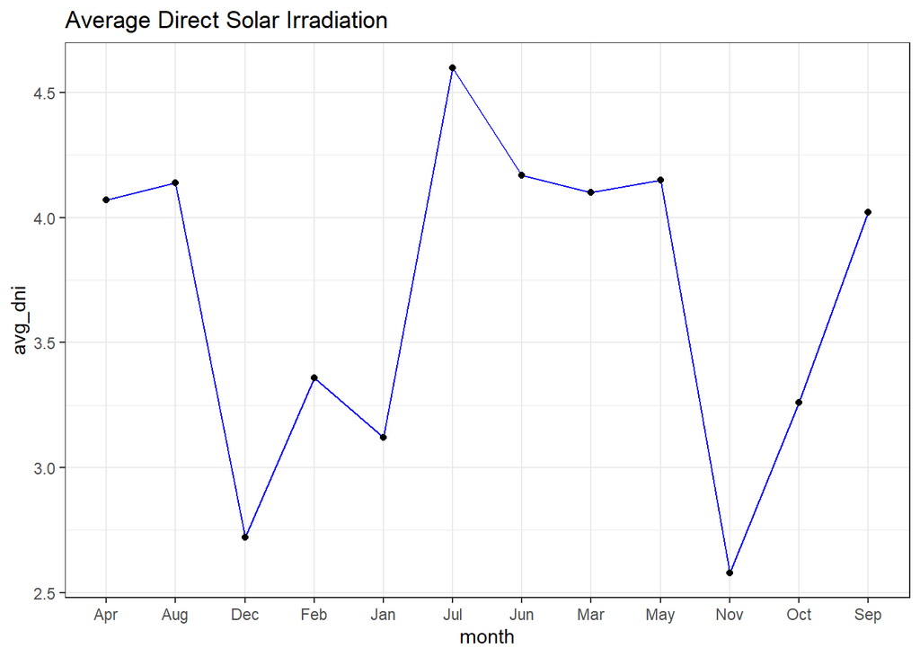

```r
# plot for each month the average direct irradiation (avg_dni) from solar_resource_df
ggplot(solar_resource_df, aes(x = month, y = avg_dni, group = 1)) +
  geom_line(color = "blue") +
  geom_point() +
  labs(
    title = "Average Direct Solar Irradiation",
    x = "month",
    y = "avg_dni"
  ) +
  theme_bw()
```

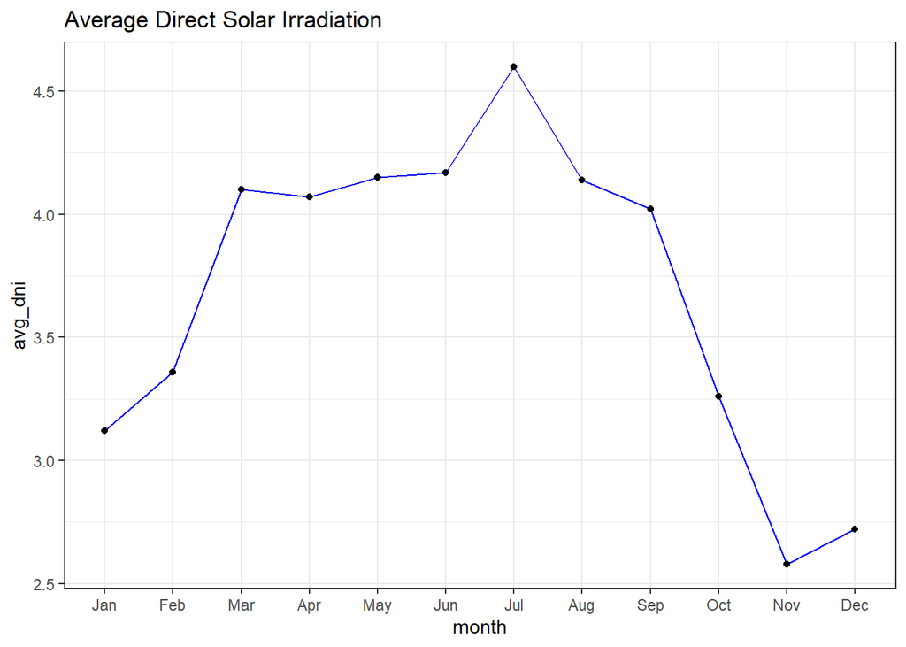

```r
# convert the month column into a factor
solar_resource_df <- solar_resource_df %>%
  mutate(month = factor(month, levels = month.abb))

# reproduce the same plot with these new settings
ggplot(solar_resource_df, aes(x = month, y = avg_dni, group = 1)) +
  geom_line(color = "blue") +
  geom_point() +
  labs(
    title = "Average Direct Solar Irradiation",
    x = "month",
    y = "avg_dni"
  ) +
  theme_bw()
```

**Observations:**  
- The average direct solar irradiation reaches the highest level around the month of July. This month corresponds to the summer season.  
- After converting the month column into a factor, we can notice that the order of the months has changed. In the first plot months are ordered alphabetically and in the second plot the months are ordered chronologically.